# Basic package description

To limit this documentation size, most figures are not displayed in the version of the vignette included in the package. To see all figures, you can rerun the vignettes, changing the following option to `TRUE`:

```r
knitr::opts_chunk$set(include = FALSE)
```

Alternatively, this compilation is also available at: http://sombrero.nathalievialaneix.eu/articles/e-doc-relationalSOM.html

## Basic package description

`SOMbrero` implements different variants of the Self-Organizing Map algorithm (also called Kohonen's algorithm). To process a given dataset with the SOM algorithm, you can use the function `trainSOM()`.

**This documentation only considers the case of dissimilarity matrices.**

### Arguments

The `trainSOM` function has several arguments, but only the first one is required. This argument is `x.data` which is the dataset used to train the SOM. In this documentation, it is passed to the function as a square matrix or data frame, which entries are dissimilarity measures between pairs of observations. The diagonal of this matrix must contain only zeros.

The other arguments are the same as the arguments passed to the `initSOM` function (they are parameters defining the algorithm, see `help(initSOM)` for further details).

### Outputs

The `trainSOM` function returns an object of class `somRes` (see `help(trainSOM)` for further details on this class).

### Graphics

The following table indicates which graphics are available for a relational SOM.

| What SOM or SC Type | SOM Energy | Obs | Prototypes | Add | SuperCluster (no what) | Obs | Prototypes | Add |
| --- | --- | --- | --- | --- | --- | --- | --- | --- |
| (no type) | x |  |  |  |  |  |  |  |
| hitmap |  | x |  |  |  | x |  |  |
| color |  |  |  | x |  |  |  |  |
| lines |  |  | x | x |  |  | x | x |
| meanline |  |  |  | x |  |  |  | x |
| barplot |  |  | x | x |  |  | x | x |
| pie |  |  |  | x |  |  |  | x |
| boxplot |  |  |  | x |  |  |  | x |
| poly.dist |  |  | x |  |  |  | x |  |
| umatrix |  |  | x |  |  |  |  |  |
| smooth.dist |  |  | x |  |  |  |  |  |
| mds |  |  | x |  |  |  | x |  |
| grid.dist |  |  | x |  |  |  |  |  |
| words |  |  |  | x |  |  |  |  |
| names |  | x |  | x |  | x |  |  |
| graph |  |  |  | x |  |  |  | x |
| projgraph |  |  |  | x |  |  |  | x |
| grid |  |  |  |  |  |  | x |  |
| dendrogram |  |  |  |  | x |  |  |  |
| dendro3d |  |  |  |  | x |  |  |  |

## Case study: the `lesmis` data set

The `lesmis` data set is based on the co-appearance graph of the characters of the novel Les Misérables (Victor Hugo). Each vertex stands for a character whose name is given by the vertex label. One edge means that the corresponding two characters appear in a common chapter in the book. Each edge also has a value indicating the number of co-appearances. The co-appearance network has been extracted by D.E. Knuth (1993).

The `lesmis` data contain two objects: the first one,`lesmis`, is an `igraph` object (see [the igraph web page](https://igraph.org/)), with 77 nodes and 254 edges.

Further information on this data set is provided with `help(lesmis)`.

```r
data(lesmis)
lesmis
```

```
## IGRAPH 3babff7 U--- 77 254 --
## + attr: layout (g/n), id (v/n), label (v/c), value (e/n)
## + edges from 3babff7:
##  [1]  1-- 2  1-- 3  1-- 4  3-- 4  1-- 5  1-- 6  1-- 7  1-- 8  1-- 9  1--10
## [11] 11--12  4--12  3--12  1--12 12--13 12--14 12--15 12--16 17--18 17--19
## [21] 18--19 17--20 18--20 19--20 17--21 18--21 19--21 20--21 17--22 18--22
## [31] 19--22 20--22 21--22 17--23 18--23 19--23 20--23 21--23 22--23 17--24
## [41] 18--24 19--24 20--24 21--24 22--24 23--24 13--24 12--24 24--25 12--25
## [51] 25--26 24--26 12--26 25--27 12--27 17--27 26--27 12--28 24--28 26--28
## [61] 25--28 27--28 12--29 28--29 24--30 28--30 12--30 24--31 31--32 12--32
## [71] 24--32 28--32 12--33 12--34 28--34 12--35 30--35 12--36 35--36 30--36
## + ... omitted several edges
```

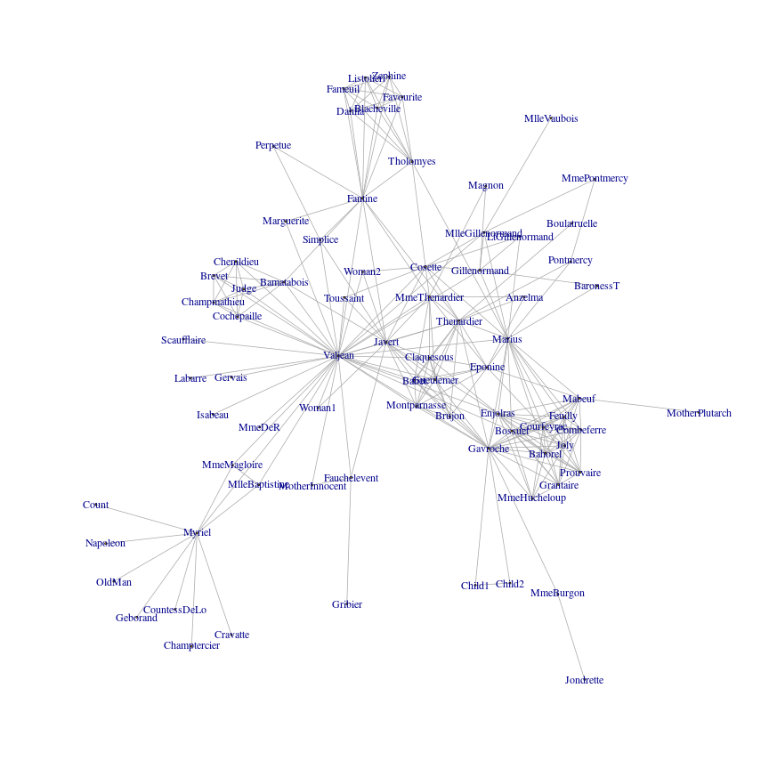

```r
plot(lesmis, vertex.size = 0)
```

The `dissim.lesmis` object is a matrix with entries equal to the length of the shortest path between two characters (obtained with the function `shortest.paths` of package `igraph`). Note that its row and column names have been initialized with the characters' names to ease the use of the graphical functions of `SOMbrero`.

### Training the SOM

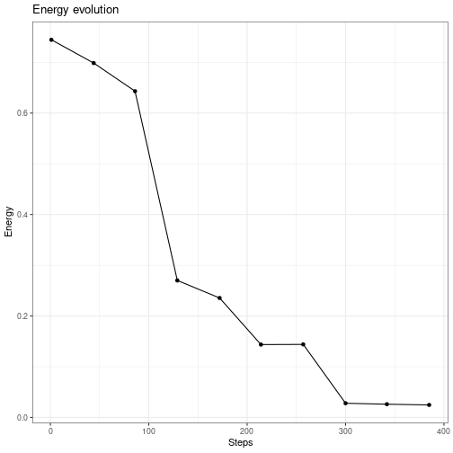

```r
set.seed(622)
mis.som <- trainSOM(x.data=dissim.lesmis, type = "relational", nb.save = 10,
                   init.proto = "random", radius.type = "letremy")
plot(mis.som, what="energy")
```

The dissimilarity matrix `dissim.lesmis` is passed to the `trainSOM` function as input. As the SOM intermediate backups have been registered (`nb.save = 10`), the energy evolution can be plotted: it stabilized in the last 100 iterations.

### Resulting clustering

The clustering component provides the classification of each of the 77 characters. The `table` function is a simple way to view data distribution on the map.

```r
mis.som$clustering
```

```
##           Myriel         Napoleon   MlleBaptistine      MmeMagloire
##               25               25               19               19
##     CountessDeLo         Geborand     Champtercier         Cravatte
##               25               25               25               25
##            Count           OldMan          Labarre          Valjean
##               25               25               22               22
##       Marguerite           MmeDeR          Isabeau          Gervais
##               16               22               23               23
##        Tholomyes        Listolier          Fameuil      Blacheville
##               11               11               11               11
##        Favourite           Dahlia          Zephine          Fantine
##               11               11               11               11
##    MmeThenardier       Thenardier          Cosette           Javert
##                2                6                7               17
##     Fauchelevent       Bamatabois         Perpetue         Simplice
##               18               21               11               17
##      Scaufflaire           Woman1            Judge     Champmathieu
##               22               22               21               21
##           Brevet       Chenildieu      Cochepaille        Pontmercy
##               21               21               21                9
##     Boulatruelle          Eponine          Anzelma           Woman2
##                6                1                2               17
##   MotherInnocent          Gribier        Jondrette        MmeBurgon
##               18               18               15               15
##         Gavroche     Gillenormand           Magnon MlleGillenormand
##               15                3                3               13
##     MmePontmercy      MlleVaubois   LtGillenormand           Marius
##                8               13                8                4
##        BaronessT           Mabeuf         Enjolras       Combeferre
##                3                5               10                5
##        Prouvaire          Feuilly       Courfeyrac          Bahorel
##               10                5                5               10
##          Bossuet             Joly        Grantaire   MotherPlutarch
##               10               10               10                5
##        Gueulemer            Babet       Claquesous     Montparnasse
##                1                1                1                1
##        Toussaint           Child1           Child2           Brujon
##               17               15               15                1
##     MmeHucheloup
##               10
```

```r
table(mis.som$clustering)
```

```
##
##  1  2  3  4  5  6  7  8  9 10 11 13 15 16 17 18 19 21 22 23 25
##  6  2  3  1  5  2  1  2  1  7  9  2  5  1  4  3  2  6  5  2  8
```

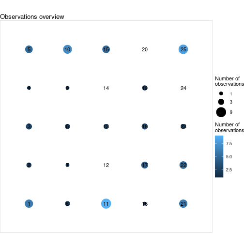

```r
plot(mis.som)
```

The clustering can be displayed using the `plot` function with `type = names`.

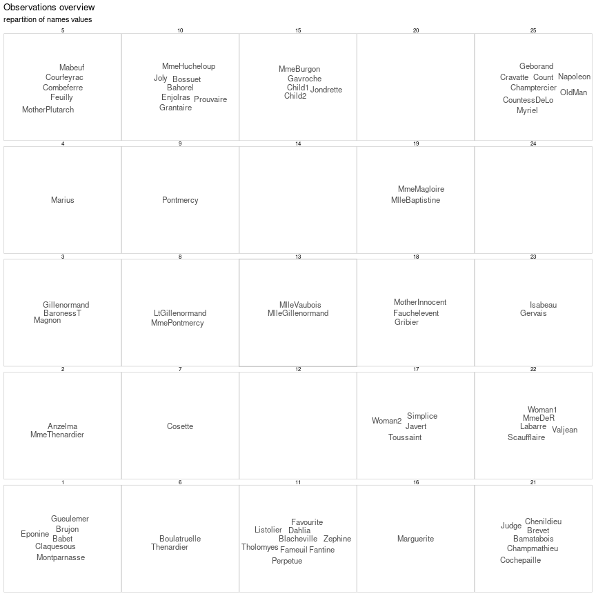

```r
plot(mis.som, what = "obs", type = "names")
```

The original graph can also be superimposed on the map:

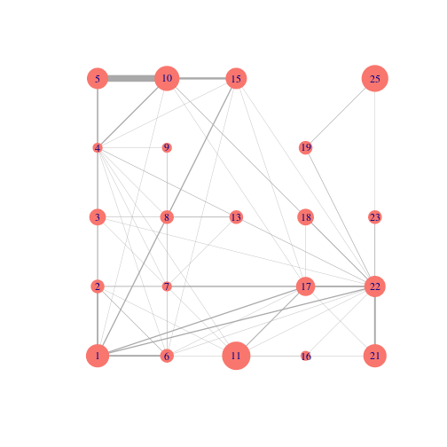

```r
plot(mis.som, what = "add", type = "graph", var = lesmis)
```

In the latter plot (which is still messy at this stage of the analysis), nodes correspond to clusters and are positioned at the cluster location on the map. The size of the nodes is proportional to the number of characters classified in this cluster and edges between nodes have a width proportional to the total weight between any two characters from the two linked clusters.

Clusters profile overviews can be plotted either with *e.g.*, lines or barplot, that both provide an information similar to that given by `"names"`.

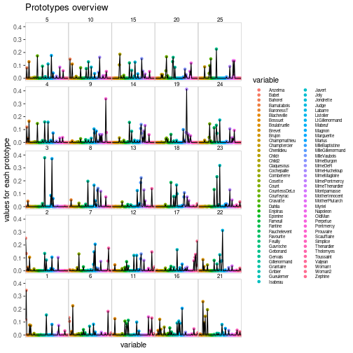

```r
plot(mis.som, what = "prototypes", type = "lines")  +
  guides(color = guide_legend(keyheight = 0.5, ncol = 2, label.theme = element_text(size = 6))) +
  theme(axis.text.x = element_blank(), axis.ticks.x = element_blank())
```

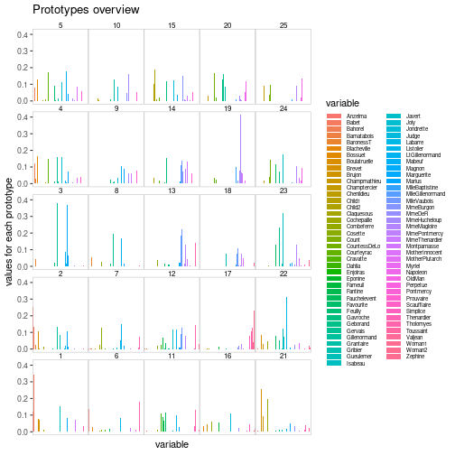

```r
plot(mis.som, what = "prototypes", type = "barplot")  +
  guides(fill = guide_legend(keyheight = 0.5, ncol = 2, label.theme = element_text(size = 6))) +
  theme(axis.text.x = element_blank(), axis.ticks.x = element_blank())
```

To see how different the clusters are, some graphics show the distances between prototypes. These graphics have exactly the same interpretation as for the other data types processed by `SOMbrero`.

- `"poly.dist"` represents the distances between neighboring prototypes with polygons plotted for each cell of the grid. The smaller the distance between a polygon's vertex and a cell border, the closer the pair of prototypes. The colors encode the number of observations in the neuron;
- `"umatrix"` fills the neurons of the grid using colors that represent the average distance between the current prototype and its neighbors;
- `"smooth.dist"` plots the mean distance between the current prototype and its neighbors with a color gradation;
- `"mds"` plots the number of the neuron on a map according to a Multi-Dimensional Scaling (MDS) projection;
- `"grid.dist"` plots a point for each pair of prototypes, with the \(x\) coordinates representing the distance between the prototypes in the input space, and \(y\) coordinates representing the distance between the corresponding neurons on the grid.

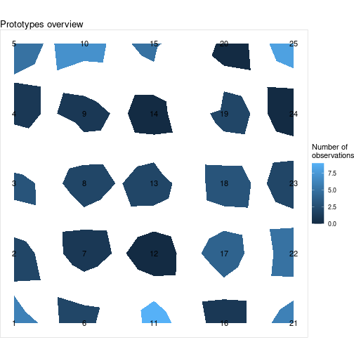

```r
plot(mis.som, what = "prototypes", type = "poly.dist")
```

Finally, with a graphical overview of the clustering

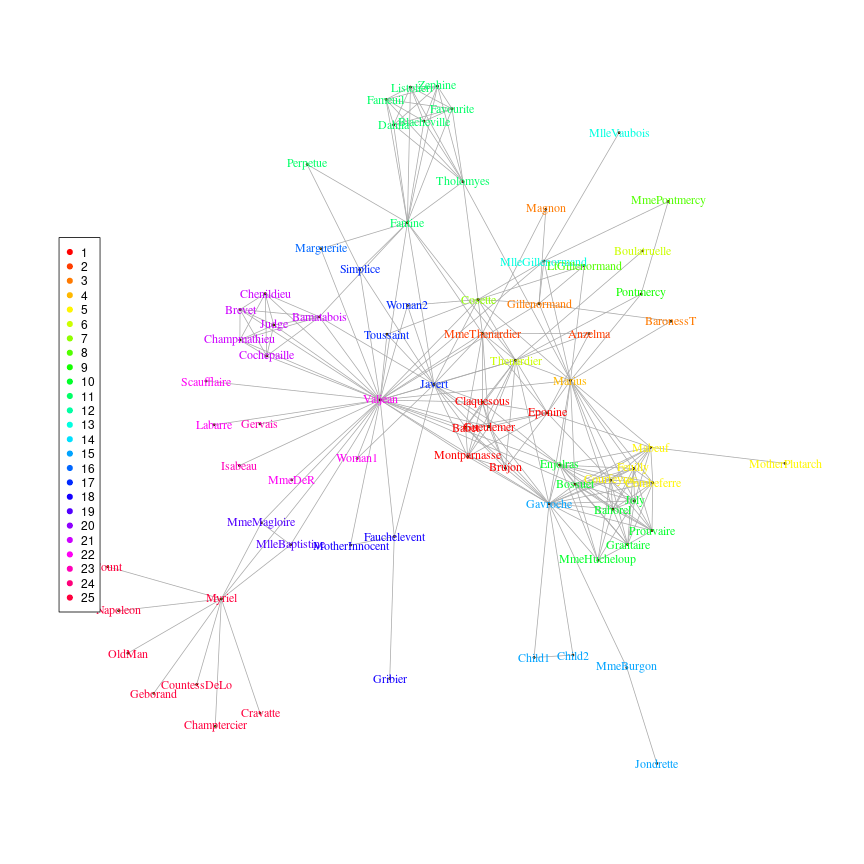

```r
plot(lesmis, vertex.label.color = rainbow(25)[mis.som$clustering],
     vertex.size = 0)
legend(x = "left", legend = 1:25, col = rainbow(25), pch = 19)
```

### Compute super clusters

As the number of clusters is rather large with the SOM algorithm, it is possible to perform a hierarchical clustering on top of SOM results. First, let us have an overview of the dendrogram:

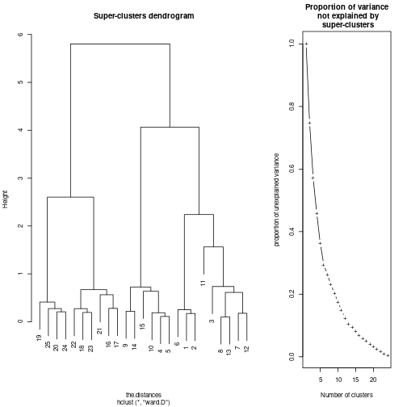

```r
plot(superClass(mis.som))
```

```r
sc.mis <- superClass(mis.som, k = 5)
summary(sc.mis)
```

```
##
##    SOM Super Classes
##      Initial number of clusters :  25
##      Number of super clusters   :  5
##
##
##   Frequency table
## 1 2 3 4 5
## 3 6 6 6 4
##
##   Clustering
##  1  2  3  4  5  6  7  8  9 10 11 12 13 14 15 16 17 18 19 20 21 22 23 24 25
##  1  1  2  3  3  1  2  2  3  3  2  2  2  3  3  4  4  4  5  5  4  4  4  5  5
##
##
##   ANOVA
##          F                       :  9.13755
##          Degrees of freedom      :  4
##          p-value                 :  5.00329e-06
##                  significativity :  ***
```

```r
table(sc.mis$cluster)
```

```
##
## 1 2 3 4 5
## 3 6 6 6 4
```

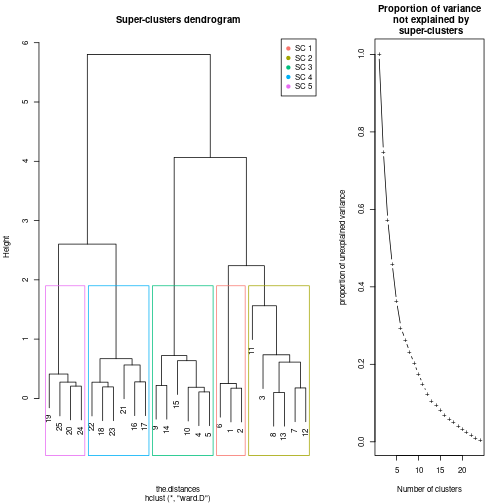

```r
plot(sc.mis)
```

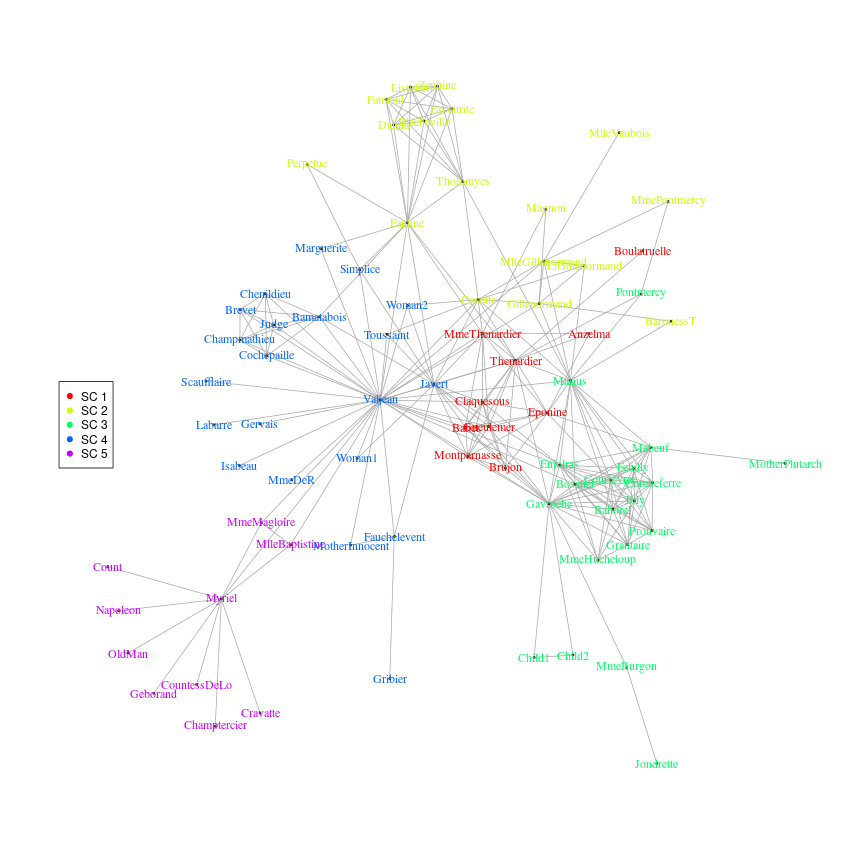

```r
plot(lesmis, vertex.size = 0,
     vertex.label.color = rainbow(5)[sc.mis$cluster[mis.som$clustering]])
legend(x = "left", legend = paste("SC", 1:5), col = rainbow(5), pch = 19)
```

SOMbrero also contains functions to compute a projected graph based on the super-clusters and to display it:

```r
projectIGraph(sc.mis, lesmis)
```

```
## IGRAPH ae6b199 UNW- 5 7 --
## + attr: layout (g/n), name (v/c), size (v/n), weight (e/n)
## + edges from ae6b199 (vertex names):
## [1] 1--2 1--3 1--4 2--3 2--4 3--4 4--5
```

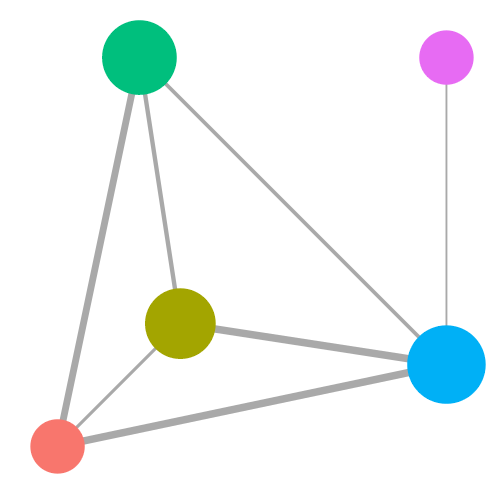

```r
par(mar = rep(0,4))
plot(sc.mis, what = "add", type = "projgraph", variable = lesmis, s.radius = 2)
```